# Data import and setup

Knit on

November 14, 2026

```r
# load libraries
library(conflicted)
library(tidyverse)
library(readxl)
library(FD)
library(MASS)
library(DT)
conflicts_prefer(dplyr::filter)
conflicts_prefer(dplyr::select)
conflicts_prefer(dplyr::recode_values)
source("functions.R")

if (!dir.exists("intermediate")) dir.create("intermediate")
```

## 1 First steps

### 1.1 Test my SU aggregation function

SUs are aggregated into subplots with side length 2:

```r
matrix(subplots(1:100, scale = 2), nrow = 10, byrow = T)
```

```
      [,1] [,2] [,3] [,4] [,5] [,6] [,7] [,8] [,9] [,10]
 [1,]    1    1    2    2    3    3    4    4    5     5
 [2,]    1    1    2    2    3    3    4    4    5     5
 [3,]    6    6    7    7    8    8    9    9   10    10
 [4,]    6    6    7    7    8    8    9    9   10    10
 [5,]   11   11   12   12   13   13   14   14   15    15
 [6,]   11   11   12   12   13   13   14   14   15    15
 [7,]   16   16   17   17   18   18   19   19   20    20
 [8,]   16   16   17   17   18   18   19   19   20    20
 [9,]   21   21   22   22   23   23   24   24   25    25
[10,]   21   21   22   22   23   23   24   24   25    25
```

### 1.2 Import vegetation data

Cover is in $cm^2$, SU of $2500~cm^2$. The cover of a species within the same subplot grouping is summed, then converted to the proportion over the total vegetated cover.

```r
data <- read_csv("Data/abundances.csv", trim_ws = T) |>
  #remove bryophythes
  filter(!species %in% c("Atrichum_undulatum", "Hypnum_cupressiforme",
  "Plagiomnium_affine", "Polytrichum_formosum", "Rhizomnium_punctatum")) |>
  #use more correct names for the plots
  mutate(plot = recode_values(plot,
                              "ABR01" ~ "01-ABR1",
                              "CAL03" ~ "03-CAL1",
                              "CAM04" ~ "04-CAM1",
                              "VEN20" ~ "20-VEN1",
                              default = plot)) |>
  #aggregate subplots in groups of 4
  mutate(subplot = subplots(SU, scale = 2)) |>
  #sum covers inside subplots
  group_by(date, plot, subplot, species) |>
  summarise(cover = sum(cover)) |>
  #convert to proportions
  mutate(cover = cover/sum(cover)) |>
  ungroup()
datatable(data)
```

|  | date | plot | subplot | species | cover |
| --- | --- | --- | --- | --- | --- |
| 1 | 1999 | 01-ABR1 | 1 | Fragaria_vesca | 0.01506024096385542 |
| 2 | 1999 | 01-ABR1 | 1 | Galium_odoratum | 0.6340361445783133 |
| 3 | 1999 | 01-ABR1 | 1 | Galium_rotundifolium | 0.3463855421686747 |
| 4 | 1999 | 01-ABR1 | 1 | Mycelis_muralis | 0.003012048192771084 |
| 5 | 1999 | 01-ABR1 | 1 | Stellaria_media | 0.001506024096385542 |
| 6 | 1999 | 01-ABR1 | 2 | Cardamine_chelidonia | 1 |
| 7 | 1999 | 01-ABR1 | 3 | Cardamine_chelidonia | 1 |
| 8 | 1999 | 01-ABR1 | 5 | Cardamine_chelidonia | 0.9375 |
| 9 | 1999 | 01-ABR1 | 5 | Stellaria_media | 0.0625 |
| 10 | 1999 | 01-ABR1 | 7 | Cardamine_chelidonia | 0.08333333333333333 |

[output cut: 3992 more lines]

Are there recorded absences?

```r
data |>
  filter(cover <= 0)
```

| date | plot | subplot | species | cover |
| --- | --- | --- | --- | --- |

No, there aren’t.

Let’s check the species names.

```r
data |>
  distinct(species) |>
  pull() |>
  sort()
##  [1] "Adoxa_moschatellina"          "Agrostis_tenuis"
##  [3] "Anemone_apennina"             "Anemone_nemorosa"
##  [5] "Anthriscus_sylvestris"        "Arisarum_proboscideum"
##  [7] "Arum_maculatum"               "Athyrium_filix-foemina"
##  [9] "Ballota_nigra"                "Cardamine_bulbifera"
## [11] "Cardamine_chelidonia"         "Cardamine_enneaphyllos"
## [13] "Cardamine_flexuosa"           "Cardamine_heptaphylla"
## [15] "Cardamine_monteluccii"        "Cardamine_trifolia"
## [17] "Carex_sylvatica"              "Chrysosplenium_alternifolium"
## [19] "Circaea_alpina"               "Cyclamen_hederifolium"
## [21] "Cyclamen_sp."                 "Daphne_laureola"
## [23] "Doronicum_columnae"           "Dryopteris_dilatata"
## [25] "Dryopteris_filix-mas"         "Epipactis_helleborine"
## [27] "Epipactis_muelleri"           "Euphorbia_amygdaloides"
## [29] "Euphorbia_corallioides"       "Euphorbia_sp."
## [31] "Festuca_drymeia"              "Festuca_heterophylla"
## [33] "Festuca_sp."                  "Fragaria_vesca"
## [35] "Galeopsis_speciosa"           "Galium_aparine"
## [37] "Galium_odoratum"              "Galium_parisiense"
## [39] "Galium_rotundifolium"         "Geranium_robertianum"
## [41] "Geranium_versicolor"          "Gymnocarpium_dryopteris"
## [43] "Hedera_helix"                 "Helleborus_foetidus"
## [45] "Hordelymus_europaeus"         "Ilex_aquifolium"
## [47] "Impatiens_noli-tangere"       "Lamiastrum_galeobdolon"
## [49] "Lamium_album"                 "Lathyrus_vernus"
## [51] "Luzula_albida"                "Luzula_forsteri"
## [53] "Lysimachia_nemorum"           "Melica_uniflora"
## [55] "Milium_effusum"               "Moehringia_trinervia"
## [57] "Monotropa_hypopitys"          "Mycelis_muralis"
## [59] "Myosotis_sylvatica"           "Neottia_nidus-avis"
## [61] "Oenanthes_pimpinelloides"     "Oxalis_acetosella"
## [63] "Polygonatum_multiflorum"      "Polygonatum_odoratum"
## [65] "Polygonatum_verticillatum"    "Polystichum_setiferum"
## [67] "Prenanthes_purpurea"          "Pteridium_aquilinum"
## [69] "Ranunculus_lanuginosus"       "Rubus_caesius"
## [71] "Rubus_fruticosus"             "Rubus_hirtus"
## [73] "Rubus_idaeus"                 "Ruscus_aculeatus"
## [75] "Sanicula_europaea"            "Stellaria_media"
## [77] "Stellaria_nemorum"            "Symphytum_tuberosum"
## [79] "Urtica_dioica"                "Veronica_chamaedrys"
## [81] "Veronica_montana"             "Vinca_minor"
## [83] "Viola_alba"                   "Viola_reichenbachiana"
## [85] "Viola_riviniana"
```

## 2 Count species and genera

Species

```r
data |>
  select(species) |>
  n_distinct()
```

```
[1] 85
```

Genera

```r
data |>
  separate_wider_delim(species, delim = "_", names = c("genus", "species")) |>
  select(genus) |>
  n_distinct()
```

```
[1] 57
```

## 3 Check the subplots before filtering

At this stage, if the number of subplots is lower it is just because there were empty subplots.

```r
before <- data |>
  distinct(date, plot, subplot) |>
  count(date, plot) |>
  pivot_wider(names_from = plot, values_from = n)
before
```

| date | 01-ABR1 | 03-CAL1 | 04-CAM1 | 20-VEN1 |
| --- | --- | --- | --- | --- |
| 1999 | 21 | 25 | 25 | 25 |
| 2000 | 19 | 25 | 25 | 25 |
| 2001 | 22 | 25 | 25 | 25 |
| 2002 | 22 | 25 | 25 | 25 |
| 2005 | 17 | 25 | 25 | 25 |
| 2006 | 17 | 25 | 25 | 25 |
| 2008 | 16 | 25 | 25 | 25 |
| 2011 | 16 | 25 | 25 | 25 |

## 4 Import the trait data

```r
traits <- read_xlsx("Data/traits.xlsx", sheet = 1) |>
  select(species:persistence, la:sm, Family, Fern_Sapro)
datatable(traits)
```

|  | species | BBRsize | offspring | spread | persistence | la | ln | ph | sla | ssd | sm | Family | Fern_Sapro |
| --- | --- | --- | --- | --- | --- | --- | --- | --- | --- | --- | --- | --- | --- |
| 1 | Adoxa_moschatellina | 10 | 4 | 13 | 1.6 | 1807.64 | 37.2424489 | 0.084653746 | 38.2413854675903 | 0.163855375 | 32.315 | Adoxaceae |  |
| 2 | Agrostis_tenuis | 18.9 | 2.7 | 7.7 | 3.6 | 167.15 | 22.56129771 | 0.26707069 | 28.1316400754013 | 0.238945838 | 0.0593 | Poaceae |  |
| 3 | Anemone_apennina | 15 | 1.8 | 1.88125 | 4 | 496 | 29.35457937 | 0.183014819 | 50.44067797 | 0.1885 | 2.3673 | Ranunculaceae |  |
| 4 | Anemone_nemorosa | 15 | 1.8 | 1.88125 | 4 | 496 | 29.35457937 | 0.183014819 | 50.44067797 | 0.1885 | 2.3673 | Ranunculaceae |  |
| 5 | Anthriscus_sylvestris | 12.9 | 1 | 0.5 | 3.2 | 4767.27689716312 | 27.96636393 | 0.83592049 | 30.5354821699739 | 0.205004764 | 4.1188 | Apiaceae |  |
| 6 | Arisarum_proboscideum | 5 | 1 | 0.5 | 1 | 1477.96 | 26.8 | 0.104 | 29.295 |  |  | Araceae |  |
| 7 | Arum_maculatum | 10.8 | 1 | 0.5 | 1.2 | 9170.61 | 42.30957338 | 0.233156255 | 32.9492416727746 | 0.103244576 | 34.9566 | Araceae |  |
| 8 | Athyrium_filix-foemina | 20 | 0.5 | 0.5 | 4 | 15575.5 | 24.49 | 0.633536272 | 56.92239 | 0.3 | 3.68e-05 | Aspleniaceae | F |
| 9 | Ballota_nigra | 10 | 0 | 0 | 0 | 717 | 23.7 | 0.600283566 | 20.265316461586 | 0.21115 | 0.8811 | Lamiaceae |  |
| 10 | Cardamine_bulbifera | 17 | 0.5 | 2.685 | 3.2 | 2676.888889 | 36.07396518 | 0.425017513 | 40.7350696566667 | 0.171804814 | 2.7 | Brassicaceae |  |

[output cut: 72 more lines]

For how many species sampled do I have traits?

```r
unique(data$species) %in% traits$species |>
  mean()
```

```
[1] 0.9647059
```

Missing species, all three of them “.sp”

```r
data |>
  distinct(species) |>
  anti_join(traits[,1])
```

| species |
| --- |
| Cyclamen_sp. |
| Euphorbia_sp. |
| Festuca_sp. |

Unnecessary/wrong species in trait data?

```r
sum(!(traits$species %in% unique(data$species)))
```

```
[1] 0
```

No.

Data only contains individuals < 1.5 m height, remove height >= 1.5

```r
traits <- traits |>
  mutate(ph = if_else(ph < 1.5, ph, NA))
```

Remove ferns and saprophytes

```r
traits <- traits |>
  filter(!Fern_Sapro %in% c("F", "Sapro") | is.na(Fern_Sapro))
traits <- traits |>
  select(!c("Family", "Fern_Sapro"))
```

### 4.1 Percent completeness across the trait table

```r
onlytraits <- traits |>
  select(!species)

#overall
100-sum(is.na(onlytraits))/prod(dim(onlytraits))*100
```

```
[1] 97.7027
```

```r
#aboveground
100-sum(is.na(onlytraits[5:10]))/prod(dim(onlytraits[5:10]))*100
```

```
[1] 96.17117
```

```r
#clonal
100-sum(is.na(onlytraits[1:4]))/prod(dim(onlytraits[1:4]))*100
```

```
[1] 100
```

```r
#by trait
incomplete_traits <- onlytraits |>
  summarise(across(everything(), ~ 100-sum(is.na(.x))/n()*100)) |>
  print() |>
  #keep going to save incomplete trait names for later
  unlist() |>
  (\(x) x[x < 100])() |>
  names()
```

```
# A tibble: 1 × 10
  BBRsize offspring spread persistence    la    ln    ph   sla   ssd    sm
    <dbl>     <dbl>  <dbl>       <dbl> <dbl> <dbl> <dbl> <dbl> <dbl> <dbl>
1     100       100    100         100  98.6  89.2   100  98.6  91.9  98.6
```

## 5 Filter SUs with missing trait data

Let’s remove subplots in which cover for unknown species (genus level records), ferns and saprophytes adds to ≥ 20%

```r
data <- data |>
  filter(species %in% traits$species) |> # keep species in traits tibble
  group_by(date, plot, subplot) |>
  mutate(tot_cover = sum(cover)) |> # total proportion after removal
  filter(tot_cover > 0.8) |> # keep if > 0.8
  select(!tot_cover) |>
  ungroup()
```

How many removed?

```r
intermediate <- data |>
  distinct(date, plot, subplot) |>
  count(date, plot) |>
  pivot_wider(names_from = plot, values_from = n)

rm_notraits <- intermediate |>
  mutate(across(2:5, ~ before[[cur_column()]] - .x))

rm_notraits
```

| date | 01-ABR1 | 03-CAL1 | 04-CAM1 | 20-VEN1 |
| --- | --- | --- | --- | --- |
| 1999 | 0 | 1 | 0 | 4 |
| 2000 | 0 | 1 | 0 | 9 |
| 2001 | 1 | 0 | 0 | 8 |
| 2002 | 0 | 0 | 0 | 6 |
| 2005 | 0 | 0 | 0 | 1 |
| 2006 | 0 | 0 | 0 | 8 |
| 2008 | 0 | 0 | 0 | 8 |
| 2011 | 1 | 0 | 0 | 6 |

## 6 Check subplot richness

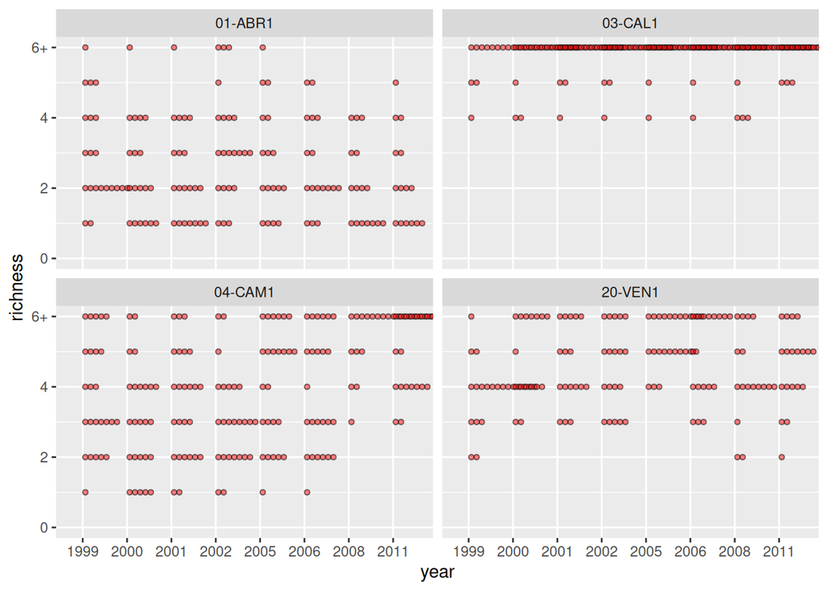

```r
data |>
  group_by(date, plot, subplot) |>
  count() |>
  ggplot(aes(x = as.factor(date), y = n))+
  geom_dotplot(binaxis = "y", binwidth = 1, method = "histodot",
               stackdir = "up", dotsize = 0.15, fill = "red",
               alpha = 0.5)+
  scale_y_continuous(limits = c(0,6), oob = scales::squish,
                     labels = c("0", "2", "4", "6+"))+
  labs(x = "year", y = "richness")+
  facet_wrap(~plot)
```

Keeping subplots with at least 4 species seems like a good compromise between having enough species for FD and not removing too many subplots:

```r
data <- data |>
  group_by(date, plot, subplot) |>
  filter(n_distinct(species) >= 4) |>
  ungroup()
```

## 7 Check subplots after filtering

This first table shows how many subplots have been removed for having few species:

```r
after <- data |>
  distinct(date, plot, subplot) |>
  count(date, plot) |>
  pivot_wider(names_from = plot, values_from = n)

rm_fewspecies <- after |>
  mutate(across(2:5, ~ intermediate[[cur_column()]] - .x))

rm_fewspecies
```

| date | 01-ABR1 | 03-CAL1 | 04-CAM1 | 20-VEN1 |
| --- | --- | --- | --- | --- |
| 1999 | 14 | 0 | 13 | 5 |
| 2000 | 14 | 0 | 15 | 2 |
| 2001 | 16 | 0 | 12 | 3 |
| 2002 | 14 | 0 | 17 | 5 |
| 2005 | 12 | 0 | 10 | 0 |
| 2006 | 12 | 0 | 13 | 3 |
| 2008 | 13 | 0 | 1 | 3 |
| 2011 | 12 | 0 | 2 | 3 |

This shows how many are there in the end:

```r
after
```

| date | 01-ABR1 | 03-CAL1 | 04-CAM1 | 20-VEN1 |
| --- | --- | --- | --- | --- |
| 1999 | 7 | 24 | 12 | 16 |
| 2000 | 5 | 24 | 10 | 14 |
| 2001 | 5 | 25 | 13 | 14 |
| 2002 | 8 | 25 | 8 | 14 |
| 2005 | 5 | 25 | 15 | 24 |
| 2006 | 5 | 25 | 12 | 14 |
| 2008 | 3 | 25 | 24 | 14 |
| 2011 | 3 | 25 | 23 | 16 |

This is the whole process: 1. initial; 2. after trait filtering; 3. after richness filtering.

```r
removal <- before |>
  left_join(intermediate, by = "date", suffix = c(".1", ".2")) |>
  left_join(after, by = "date") |>
  rename_with(~ paste0(., ".3"), -c(date, ends_with(c(".1", ".2"))))

removal <- removal |>
  select(date, sort(names(removal)[-1]))

removal
```

| date | 01-ABR1.1 | 01-ABR1.2 | 01-ABR1.3 | 03-CAL1.1 | 03-CAL1.2 | 03-CAL1.3 | 04-CAM1.1 | 04-CAM1.2 | 04-CAM1.3 | 20-VEN1.1 | 20-VEN1.2 | 20-VEN1.3 |
| --- | --- | --- | --- | --- | --- | --- | --- | --- | --- | --- | --- | --- |
| 1999 | 21 | 21 | 7 | 25 | 24 | 24 | 25 | 25 | 12 | 25 | 21 | 16 |
| 2000 | 19 | 19 | 5 | 25 | 24 | 24 | 25 | 25 | 10 | 25 | 16 | 14 |
| 2001 | 22 | 21 | 5 | 25 | 25 | 25 | 25 | 25 | 13 | 25 | 17 | 14 |
| 2002 | 22 | 22 | 8 | 25 | 25 | 25 | 25 | 25 | 8 | 25 | 19 | 14 |
| 2005 | 17 | 17 | 5 | 25 | 25 | 25 | 25 | 25 | 15 | 25 | 24 | 24 |
| 2006 | 17 | 17 | 5 | 25 | 25 | 25 | 25 | 25 | 12 | 25 | 17 | 14 |
| 2008 | 16 | 16 | 3 | 25 | 25 | 25 | 25 | 25 | 24 | 25 | 17 | 14 |
| 2011 | 16 | 15 | 3 | 25 | 25 | 25 | 25 | 25 | 23 | 25 | 19 | 16 |

Restore subplot sums = 1 after removal

```r
data <- data |>
  group_by(date, plot, subplot) |>
  mutate(cover = cover/sum(cover)) |>
  ungroup()
```

## 8 What’s the richness in each plot and year?

This is the richness after removal.

```r
data |>
  count(date, plot, species) |>
  count(date, plot) |>
  pivot_wider(names_from = plot, values_from = n)
```

| date | 01-ABR1 | 03-CAL1 | 04-CAM1 | 20-VEN1 |
| --- | --- | --- | --- | --- |
| 1999 | 11 | 23 | 17 | 11 |
| 2000 | 8 | 23 | 11 | 16 |
| 2001 | 9 | 23 | 17 | 13 |
| 2002 | 11 | 23 | 14 | 16 |
| 2005 | 9 | 22 | 16 | 20 |
| 2006 | 9 | 21 | 15 | 16 |
| 2008 | 7 | 17 | 21 | 14 |
| 2011 | 7 | 19 | 21 | 13 |

## 9 Convert to wide format for randomizations

```r
data <- data |>
  pivot_wider(names_from = species, values_from = cover, values_fill = 0)
datatable(data)
```

|  | date | plot | subplot | Fragaria_vesca | Galium_odoratum | Galium_rotundifolium | Mycelis_muralis | Stellaria_media | Cardamine_chelidonia | Cardamine_bulbifera | Rubus_caesius | Viola_riviniana | Sanicula_europaea | Veronica_montana | Hedera_helix | Milium_effusum | Rubus_fruticosus | Ruscus_aculeatus | Vinca_minor | Lamiastrum_galeobdolon | Viola_reichenbachiana | Geranium_robertianum | Melica_uniflora | Geranium_versicolor | Oxalis_acetosella | Euphorbia_corallioides | Arisarum_proboscideum | Euphorbia_amygdaloides | Lysimachia_nemorum | … |
| --- | --- | --- | --- | --- | --- | --- | --- | --- | --- | --- | --- | --- | --- | --- | --- | --- | --- | --- | --- | --- | --- | --- | --- | --- | --- | --- | --- | --- | --- | --- |
| 1 | 1999 | 01-ABR1 | 1 | 0.01506024096385542 | 0.6340361445783133 | 0.3463855421686747 | 0.003012048192771084 | 0.001506024096385542 | 0 | 0 | 0 | 0 | 0 | 0 | 0 | 0 | 0 | 0 | 0 | 0 | 0 | 0 | 0 | 0 | 0 | 0 | 0 | 0 | 0 | … |
| 2 | 1999 | 01-ABR1 | 13 | 0.01675977653631285 | 0.976536312849162 | 0 | 0.004469273743016759 | 0 | 0.00223463687150838 | 0 | 0 | 0 | 0 | 0 | 0 | 0 | 0 | 0 | 0 | 0 | 0 | 0 | 0 | 0 | 0 | 0 | 0 | 0 | 0 | … |
| 3 | 1999 | 01-ABR1 | 14 | 0.03305785123966942 | 0.7272727272727273 | 0 | 0 | 0 | 0.008264462809917356 | 0.0743801652892562 | 0.0743801652892562 | 0.08264462809917356 | 0 | 0 | 0 | 0 | 0 | 0 | 0 | 0 | 0 | 0 | 0 | 0 | 0 | 0 | 0 | 0 | 0 | … |
| 4 | 1999 | 01-ABR1 | 15 | 0.3153846153846154 | 0.4230769230769231 | 0 | 0 | 0 | 0 | 0.01538461538461539 | 0.2346153846153846 | 0 | 0.01153846153846154 | 0 | 0 | 0 | 0 | 0 | 0 | 0 | 0 | 0 | 0 | 0 | 0 | 0 | 0 | 0 | 0 | … |
| 5 | 1999 | 01-ABR1 | 19 | 0.3235294117647059 | 0.01260504201680672 | 0 | 0 | 0 | 0 | 0 | 0 | 0.3991596638655462 | 0.1596638655462185 | 0.1050420168067227 | 0 | 0 | 0 | 0 | 0 | 0 | 0 | 0 | 0 | 0 | 0 | 0 | 0 | 0 | 0 | … |
| 6 | 1999 | 01-ABR1 | 22 | 0.1273885350318471 | 0.8535031847133758 | 0 | 0 | 0.01273885350318471 | 0.006369426751592357 | 0 | 0 | 0 | 0 | 0 | 0 | 0 | 0 | 0 | 0 | 0 | 0 | 0 | 0 | 0 | 0 | 0 | 0 | 0 | 0 | … |
| 7 | 1999 | 01-ABR1 | 23 | 0.001829826166514181 | 0.9542543458371455 | 0 | 0 | 0 | 0.0009149130832570906 | 0 | 0 | 0.04300091491308326 | 0 | 0 | 0 | 0 | 0 | 0 | 0 | 0 | 0 | 0 | 0 | 0 | 0 | 0 | 0 | 0 | 0 | … |
| 8 | 1999 | 03-CAL1 | 1 | 0 | 0.02839564600094652 | 0 | 0 | 0 | 0 | 0 | 0 | 0 | 0 | 0 | 0.0236630383341221 | 0.0979649787032655 | 0.1183151916706105 | 0.5016564126833886 | 0.2300047326076668 | 0 | 0 | 0 | 0 | 0 | 0 | 0 | 0 | 0 | 0 | … |
| 9 | 1999 | 03-CAL1 | 2 | 0 | 0.04937027707808564 | 0 | 0 | 0 | 0 | 0 | 0 | 0 | 0 | 0 | 0.07052896725440806 | 0.03778337531486146 | 0 | 0.6045340050377834 | 0.2216624685138539 | 0.01612090680100756 | 0 | 0 | 0 | 0 | 0 | 0 | 0 | 0 | 0 | … |
| 10 | 1999 | 03-CAL1 | 3 | 0 | 0.02622950819672131 | 0 | 0 | 0 | 0 | 0 | 0 | 0 | 0 | 0 | 0.1836065573770492 | 0 | 0.01639344262295082 | 0.6918032786885245 | 0.08196721311475409 | 0 | 0 | 0 | 0 | 0 | 0 | 0 | 0 | 0 | 0 | … |

[output cut: 472 more lines]

## 10 Trait transformations

I’m using Box-Cox with $\lambda$ chosen by maximum likelihood. First a check:

```r
traits |>
  summarise(across(where(is.numeric), ~ boxcox(., check = T)))
```

| BBRsize | offspring | spread | persistence | la | ln | ph | sla | ssd | sm |
| --- | --- | --- | --- | --- | --- | --- | --- | --- | --- |
| 0.6 | -0.3 | -0.3 | 1.3 | 0.1 | -0.1 | 0 | 0.3 | -0.7 | 0.1 |

- ~ no transform persistence
- ~ 1/sqrt offspring, spread, ssd
- ~ sqrt BBRsize, sla
- ~ log la, ln, height, sm

Now let’s actually transform:

```r
traits <- traits |>
  mutate(across(where(is.numeric),  ~ boxcox(.)))
```

Check the distributions.

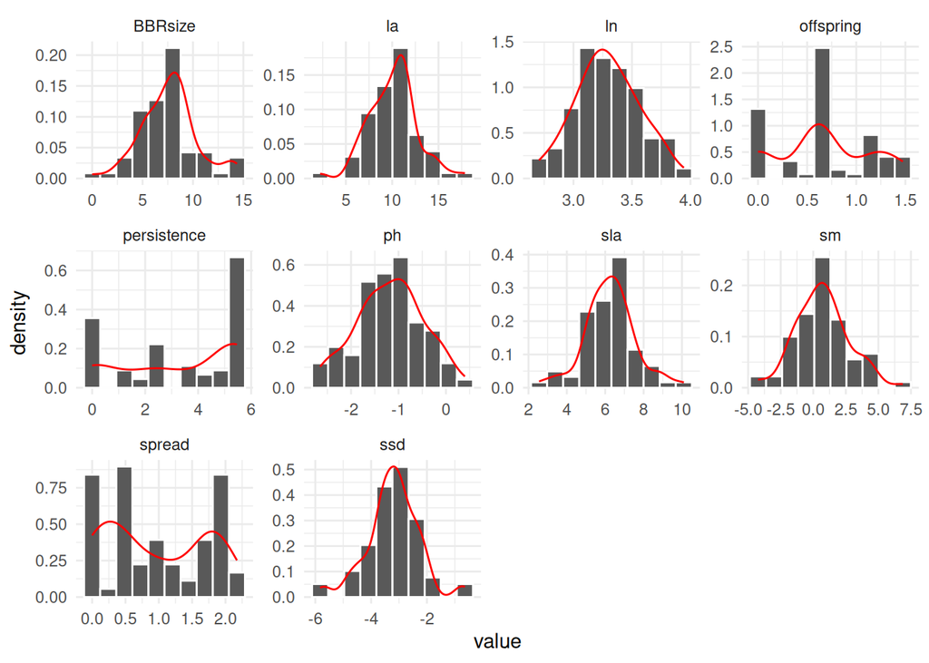

```r
traits |>
  select(species | where(is.numeric)) |>
  pivot_longer(-species, names_to = "trait", values_to = "value") |>
  histdensity(value)+
  facet_wrap(~ trait, scales = "free")+
  theme_minimal()
```

## 11 Calculate dissimilarity matrices

Species names to name the matrices

```r
species <- traits$species
```

### 11.1 Above-ground matrix

Gower distance using only the six aboveground traits

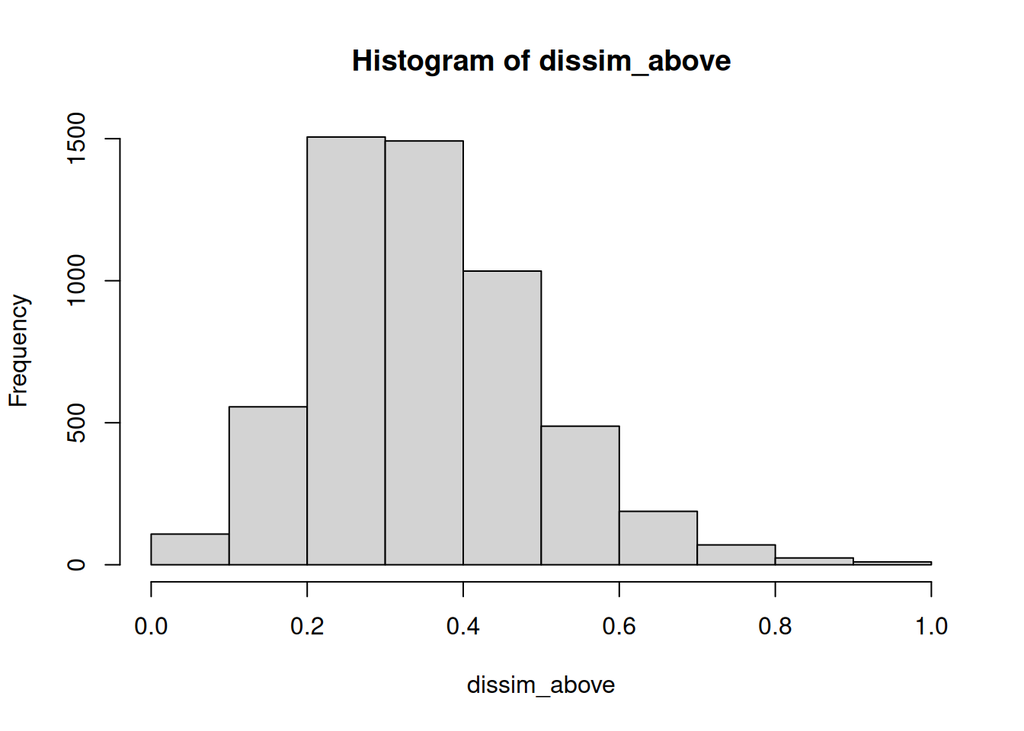

```r
dissim_above <- traits |>
  select(la:sm) |>
  gowdis() |>
  as.matrix()
dimnames(dissim_above) <- list(species, species)

#scale by maximum value
dissim_above <- dissim_above/max(dissim_above)

hist(dissim_above)
```

### 11.2 Below-ground matrix

Gower distance using only the four clonal traits

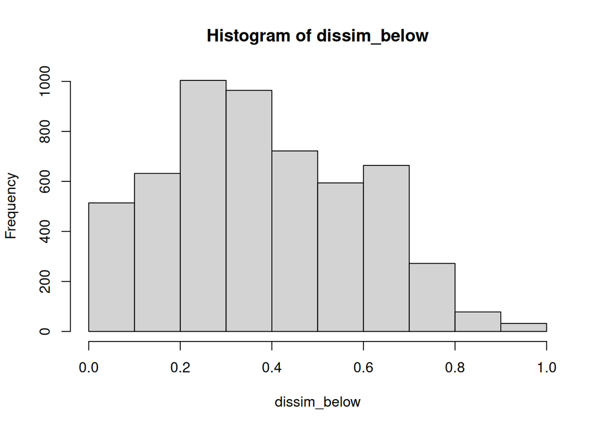

```r
dissim_below <- traits |>
  select(BBRsize:persistence) |>
  gowdis() |>
  as.matrix()

dimnames(dissim_below) <- list(species, species)

#scale by maximum value
dissim_below <- dissim_below/max(dissim_below)

hist(dissim_below)
```

### 11.3 Overall matrix

Average of the two so that each compartment has the same weight

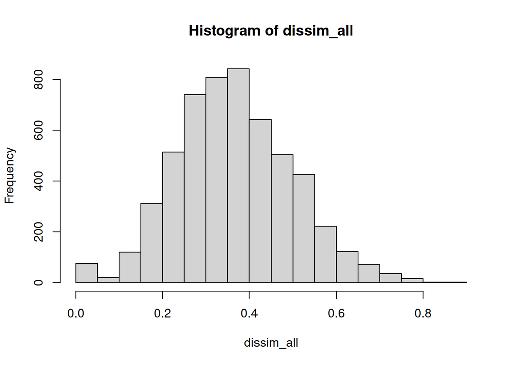

```r
dissim_all <- (dissim_above + dissim_below) / 2

dimnames(dissim_all) <- list(species, species)

hist(dissim_all)
```

I’ll put all three dissims into a list

```r
dissims <- list(overall = dissim_all, above = dissim_above, below = dissim_below)
```

## 12 Save output

```r
save(data, traits, dissims, file = "intermediate/data.RData")
```